# R Notebook for Data Viz for Clinical Data

We are using a common dataset across the R and Python coding examples.

The code below reads in the csv file final_with_deceased.csv. It also calls the libraries we are going to use.

```r
library(ggplot2)
library(dplyr)
library(tidyr)

mydata <- as.data.frame(read.csv("final_with_deceased.csv"))
```

The first step when working with a data file is an exploratory data analysis.

```r
head(mydata, 5) # prints first five rows
```

|  | person_id | birth_datetime | race_source_value | ethnicity_source_value | gender_source_value | visit_occurrence_id | visit_start_date | visit_end_date | visit_type | condition | observation_source | age_at_visit_years | measurement_Date | body_height_cm | bmi | body_temperature_c | body_weight_kg | systolic | diastolic | heart_rate_bpm | oxygen_saturation_percent | respiratory_rate_per_minute | flu_last_administered | tdap_last_administered | mmr_last_administered | polio_last_administered | deceased |
| --- | --- | --- | --- | --- | --- | --- | --- | --- | --- | --- | --- | --- | --- | --- | --- | --- | --- | --- | --- | --- | --- | --- | --- | --- | --- | --- | --- |
| 1 | 1 | 1958-12-02 | white | nonhispanic | F | 1 | 2020-03-11 | 2020-04-01 | Inpatient Visit | Dyspnea:Pneumonia:Respiratory distress:Wheezing | Suspected COVID-19 | 61.27 | 2020-03-11 | NA | NA | 40.2 | 71.3 | 132 | 81 | 178.9 | 84.8 | 37.0 | 2019-09-11 | 2010-12-02 | 1962-12-02 | 1962-12-02 | Y |
| 2 | 2 | 1945-10-02 | white | nonhispanic | F | 28 | 2020-05-07 | 2020-05-07 | Outpatient Visit | Viral sinusitis |  | 74.60 |  | NA | NA | NA | NA | NA | NA | NA | NA | NA | 2019-12-04 | 2017-10-02 | 1949-10-02 | 1949-10-02 | N |
| 3 | 3 | 1968-04-20 | white | nonhispanic | M | 188 | 2020-03-15 | 2020-03-15 | Outpatient Visit | Sore throat symptom:Dyspnea:Wheezing | Suspected COVID-19 | 51.90 | 2020-03-14 | NA | NA | 42.2 | 91.9 | 108 | 76 | 57.1 | 78.4 | 32.1 | 2019-11-19 | 2010-04-20 | 1972-04-20 | 1972-04-20 | N |
| 4 | 5 | 1988-08-09 | white | nonhispanic | F | 198 | 1992-08-15 | 1992-08-29 | Outpatient Visit | Perennial allergic rhinitis |  | 4.02 |  | NA | NA | NA | NA | NA | NA | NA | NA | NA | 1991-10-24 |  | 1992-08-09 | 1992-08-09 | N |
| 5 | 5 | 1988-08-09 | white | nonhispanic | F | 206 | 2020-03-10 | 2020-03-10 | Outpatient Visit | Cough | Suspected COVID-19 | 31.58 | 2020-03-10 | NA | NA | 41.6 | 74.4 | 130 | 84 | 132.8 | 88.4 | 14.4 | 2019-10-23 | 2010-08-09 | 1992-08-09 | 1992-08-09 | Y |

```r
tail(mydata, 5) # prints last five rows
```

|  | person_id | birth_datetime | race_source_value | ethnicity_source_value | gender_source_value | visit_occurrence_id | visit_start_date | visit_end_date | visit_type | condition | observation_source | age_at_visit_years | measurement_Date | body_height_cm | bmi | body_temperature_c | body_weight_kg | systolic | diastolic | heart_rate_bpm | oxygen_saturation_percent | respiratory_rate_per_minute | flu_last_administered | tdap_last_administered | mmr_last_administered | polio_last_administered | deceased |
| --- | --- | --- | --- | --- | --- | --- | --- | --- | --- | --- | --- | --- | --- | --- | --- | --- | --- | --- | --- | --- | --- | --- | --- | --- | --- | --- | --- |
| 156026 | 124148 | 2017-08-11 | white | nonhispanic | M | 3139386 | 2020-03-08 | 2020-03-08 | Outpatient Visit | Cough | Suspected COVID-19 | 2.57 | 2020-03-08 | NA | NA | 39.4 | 12.2 | 108 | 83 | 170.0 | 84.8 | 32.6 | 2019-12-27 |  | 2018-08-11 | 2018-02-11 | N |
| 156027 | 124149 | 1948-12-16 | black | nonhispanic | F | 3139391 | 2019-10-23 | 2019-10-23 | Outpatient Visit | Viral sinusitis |  | 70.85 |  | NA | NA | NA | NA | NA | NA | NA | NA | NA | 2018-12-08 | 2010-12-16 | 1952-12-16 | 1952-12-16 | N |
| 156028 | 124149 | 1948-12-16 | black | nonhispanic | F | 3139397 | 2020-02-14 | 2020-03-06 | Inpatient Visit | Acute respiratory failure:Pneumonia:Respiratory distress:Cough | Suspected COVID-19 | 71.16 | 2020-02-14 | NA | NA | 39.0 | 77.1 | 119 | 73 | 149.8 | 87.5 | 13.6 | 2019-12-12 | 2010-12-16 | 1952-12-16 | 1952-12-16 | N |
| 156029 | 124149 | 1948-12-16 | black | nonhispanic | F | 3139393 | 2020-03-17 | 2020-03-17 | Outpatient Visit | Viral sinusitis |  | 71.25 |  | NA | NA | NA | NA | NA | NA | NA | NA | NA | 2019-12-04 | 2010-12-16 | 1952-12-16 | 1952-12-16 | N |
| 156030 | 124150 | 1964-09-09 | white | nonhispanic | M | 3139398 | 2020-03-07 | 2020-03-26 | Inpatient Visit | Wheezing:Cough:Respiratory distress:Pneumonia:Dyspnea | Suspected COVID-19 | 55.49 | 2020-03-07 | NA | NA | 37.9 | 77.9 | 122 | 82 | 64.8 | 80.5 | 12.8 | 2019-12-14 | 2016-09-09 | 1968-09-09 | 1968-09-09 | N |

```r
sample_n(mydata, 5) # prints five randomly selected rows
```

| person_id | birth_datetime | race_source_value | ethnicity_source_value | gender_source_value | visit_occurrence_id | visit_start_date | visit_end_date | visit_type | condition | observation_source | age_at_visit_years | measurement_Date | body_height_cm | bmi | body_temperature_c | body_weight_kg | systolic | diastolic | heart_rate_bpm | oxygen_saturation_percent | respiratory_rate_per_minute | flu_last_administered | tdap_last_administered | mmr_last_administered | polio_last_administered | deceased |
| --- | --- | --- | --- | --- | --- | --- | --- | --- | --- | --- | --- | --- | --- | --- | --- | --- | --- | --- | --- | --- | --- | --- | --- | --- | --- | --- |
| 111271 | 2013-08-29 | white | nonhispanic | F | 2807496 | 2017-09-04 | 2017-09-04 | Outpatient Visit | Childhood asthma |  | 4.02 |  | NA | NA | NA | NA | NA | NA | NA | NA | NA | 2016-10-10 |  | 2017-08-29 | 2017-08-29 | N |
| 61587 | 1993-06-27 | white | nonhispanic | F | 1554443 | 2020-04-05 | 2020-04-05 | Outpatient Visit | Streptococcal sore throat |  | 26.77 | 2020-04-04 | NA | NA | 37.4 | NA | NA | NA | NA | NA | NA | 2019-11-02 | 2015-06-27 | 1997-06-27 | 1997-06-27 | N |
| 115712 | 1988-11-15 | white | nonhispanic | M | 2918501 | 2019-03-20 | 2019-03-20 | Outpatient Visit | Sinusitis |  | 30.34 |  | NA | NA | NA | NA | NA | NA | NA | NA | NA | 2018-11-22 | 2010-11-15 | 1992-11-15 | 1992-11-15 | N |
| 41674 | 1962-07-26 | white | hispanic | M | 1057983 | 2020-02-28 | 2020-03-13 | Inpatient Visit | Respiratory distress:Pneumonia | Suspected COVID-19 | 57.59 | 2020-02-28 | NA | NA | 40.9 | 98.8 | 113 | 77 | 152.8 | 79.9 | 14.4 | 2019-11-26 | 2014-07-26 | 1966-07-26 | 1966-07-26 | N |
| 72142 | 1983-06-19 | asian | nonhispanic | F | 1812785 | 2020-02-25 | 2020-02-25 | Outpatient Visit | Cough | Suspected COVID-19 | 36.69 | 2020-02-25 | NA | NA | 42.1 | 77.9 | 108 | 71 | 139.3 | 83.0 | 35.2 | 2019-11-05 | 2015-06-19 | 1987-06-19 | 1987-06-19 | N |

```r
print(dim(mydata)) # print number of columns and rows
```

```
[1] 156030     27
```

```r
summary(mydata) # overview of each variable in the dataset
```

```
   person_id      birth_datetime     race_source_value  ethnicity_source_value gender_source_value visit_occurrence_id
 Min.   :     1   Length:156030      Length:156030      Length:156030          Length:156030       Min.   :      1
 1st Qu.: 30962   Class :character   Class :character   Class :character       Class :character    1st Qu.: 782279
 Median : 62112   Mode  :character   Mode  :character   Mode  :character       Mode  :character    Median :1566715
 Mean   : 62078                                                                                    Mean   :1566862
 3rd Qu.: 93254                                                                                    3rd Qu.:2358876
 Max.   :124150                                                                                    Max.   :3139398

 visit_start_date   visit_end_date      visit_type         condition         observation_source age_at_visit_years
 Length:156030      Length:156030      Length:156030      Length:156030      Length:156030      Min.   :  0.01
 Class :character   Class :character   Class :character   Class :character   Class :character   1st Qu.: 16.16
 Mode  :character   Mode  :character   Mode  :character   Mode  :character   Mode  :character   Median : 36.07
                                                                                                Mean   : 37.86
                                                                                                3rd Qu.: 57.17
                                                                                                Max.   :110.73

 measurement_Date   body_height_cm        bmi         body_temperature_c body_weight_kg      systolic       diastolic
 Length:156030      Min.   : 50.6    Min.   :12.70    Min.   :36.1       Min.   :  1.80   Min.   : 97.0   Min.   : 67.00
 Class :character   1st Qu.:159.7    1st Qu.:27.20    1st Qu.:38.5       1st Qu.: 66.80   1st Qu.:113.0   1st Qu.: 76.00
 Mode  :character   Median :167.7    Median :28.00    Median :39.7       Median : 78.00   Median :120.0   Median : 80.00
                    Mean   :163.1    Mean   :27.24    Mean   :39.7       Mean   : 73.22   Mean   :121.3   Mean   : 80.42
                    3rd Qu.:176.1    3rd Qu.:29.80    3rd Qu.:40.9       3rd Qu.: 87.40   3rd Qu.:128.0   3rd Qu.: 84.00
                    Max.   :198.7    Max.   :53.30    Max.   :42.2       Max.   :181.20   Max.   :201.0   Max.   :121.00
                    NA's   :152974   NA's   :153062   NA's   :70085      NA's   :76295    NA's   :76285   NA's   :76285
 heart_rate_bpm  oxygen_saturation_percent respiratory_rate_per_minute flu_last_administered tdap_last_administered
 Min.   : 50.0   Min.   :66.10             Min.   :12.00               Length:156030         Length:156030
 1st Qu.: 85.1   1st Qu.:78.50             1st Qu.:18.20               Class :character      Class :character
 Median :122.0   Median :82.00             Median :25.50               Mode  :character      Mode  :character
 Mean   :123.4   Mean   :82.01             Mean   :25.56
 3rd Qu.:161.5   3rd Qu.:85.50             3rd Qu.:32.70
 Max.   :200.0   Max.   :89.00             Max.   :40.00
 NA's   :76295   NA's   :79221             NA's   :76295
 mmr_last_administered polio_last_administered   deceased
 Length:156030         Length:156030           Length:156030
 Class :character      Class :character        Class :character
 Mode  :character      Mode  :character        Mode  :character
```

All of our dates are character variables, so let’s convert those to dates.

```r
mydata <- mydata %>%
            mutate(visit_start_date = as.Date(visit_start_date)) %>%
            mutate(visit_end_date = as.Date(visit_end_date) ) %>%
            mutate(birth_datetime = as.Date(birth_datetime)) %>%
            mutate(flu_last_administered = as.Date(flu_last_administered) ) %>%
            mutate(tdap_last_administered = as.Date(tdap_last_administered) ) %>%
            mutate(mmr_last_administered = as.Date(mmr_last_administered)) %>%
            mutate(polio_last_administered = as.Date(polio_last_administered))

summary(mydata)
```

```
   person_id      birth_datetime       race_source_value  ethnicity_source_value gender_source_value visit_occurrence_id
 Min.   :     1   Min.   :1909-06-24   Length:156030      Length:156030          Length:156030       Min.   :      1
 1st Qu.: 30962   1st Qu.:1953-03-09   Class :character   Class :character       Class :character    1st Qu.: 782279
 Median : 62112   Median :1971-06-14   Mode  :character   Mode  :character       Mode  :character    Median :1566715
 Mean   : 62078   Mean   :1971-12-17                                                                 Mean   :1566862
 3rd Qu.: 93254   3rd Qu.:1994-04-29                                                                 3rd Qu.:2358876
 Max.   :124150   Max.   :2020-04-21                                                                 Max.   :3139398

 visit_start_date     visit_end_date        visit_type         condition         observation_source age_at_visit_years
 Min.   :1909-09-17   Min.   :1909-09-17   Length:156030      Length:156030      Length:156030      Min.   :  0.01
 1st Qu.:2007-05-16   1st Qu.:2007-10-26   Class :character   Class :character   Class :character   1st Qu.: 16.16
 Median :2020-02-22   Median :2020-02-24   Mode  :character   Mode  :character   Mode  :character   Median : 36.07
 Mean   :2009-10-28   Mean   :2009-12-29                                                            Mean   : 37.86
 3rd Qu.:2020-03-07   3rd Qu.:2020-03-09                                                            3rd Qu.: 57.17
 Max.   :2020-05-26   Max.   :2020-05-27                                                            Max.   :110.73

 measurement_Date   body_height_cm        bmi         body_temperature_c body_weight_kg      systolic       diastolic
 Length:156030      Min.   : 50.6    Min.   :12.70    Min.   :36.1       Min.   :  1.80   Min.   : 97.0   Min.   : 67.00
 Class :character   1st Qu.:159.7    1st Qu.:27.20    1st Qu.:38.5       1st Qu.: 66.80   1st Qu.:113.0   1st Qu.: 76.00
 Mode  :character   Median :167.7    Median :28.00    Median :39.7       Median : 78.00   Median :120.0   Median : 80.00
                    Mean   :163.1    Mean   :27.24    Mean   :39.7       Mean   : 73.22   Mean   :121.3   Mean   : 80.42
                    3rd Qu.:176.1    3rd Qu.:29.80    3rd Qu.:40.9       3rd Qu.: 87.40   3rd Qu.:128.0   3rd Qu.: 84.00
                    Max.   :198.7    Max.   :53.30    Max.   :42.2       Max.   :181.20   Max.   :201.0   Max.   :121.00
                    NA's   :152974   NA's   :153062   NA's   :70085      NA's   :76295    NA's   :76285   NA's   :76285
 heart_rate_bpm  oxygen_saturation_percent respiratory_rate_per_minute flu_last_administered tdap_last_administered
 Min.   : 50.0   Min.   :66.10             Min.   :12.00               Min.   :1908-10-06    Min.   :1921-06-24
 1st Qu.: 85.1   1st Qu.:78.50             1st Qu.:18.20               1st Qu.:2006-10-14    1st Qu.:2009-09-19
 Median :122.0   Median :82.00             Median :25.50               Median :2019-09-13    Median :2013-06-11
 Mean   :123.4   Mean   :82.01             Mean   :25.56               Mean   :2009-04-26    Mean   :2007-07-04
 3rd Qu.:161.5   3rd Qu.:85.50             3rd Qu.:32.70               3rd Qu.:2019-11-07    3rd Qu.:2016-11-04
 Max.   :200.0   Max.   :89.00             Max.   :40.00               Max.   :2019-12-31    Max.   :2020-05-25
 NA's   :76295   NA's   :79221             NA's   :76295                                     NA's   :31146
 mmr_last_administered polio_last_administered   deceased
 Min.   :1910-07-21    Min.   :1909-09-11      Length:156030
 1st Qu.:1956-12-04    1st Qu.:1957-01-03      Class :character
 Median :1975-01-21    Median :1975-04-08      Mode  :character
 Mean   :1975-06-06    Mean   :1975-08-21
 3rd Qu.:1997-09-01    3rd Qu.:1998-01-02
 Max.   :2020-05-19    Max.   :2020-05-25
 NA's   :1807          NA's   :228
```

Next, lets look into any missing data.

```r
n <- nrow(mydata) # n is number of rows (observations)

missing_count <- colSums(is.na(mydata)) # calculate number missing
missing_pct <- missing_count/n * 100 # calculate percent missing
non_missing_count <- n - missing_count # calculate number non-missing

print(cbind(missing_count, missing_pct, non_missing_count))
```

```
                            missing_count missing_pct non_missing_count
person_id                               0   0.0000000            156030
birth_datetime                          0   0.0000000            156030
race_source_value                       0   0.0000000            156030
ethnicity_source_value                  0   0.0000000            156030
gender_source_value                     0   0.0000000            156030
visit_occurrence_id                     0   0.0000000            156030
visit_start_date                        0   0.0000000            156030
visit_end_date                          0   0.0000000            156030
visit_type                              0   0.0000000            156030
condition                               0   0.0000000            156030
observation_source                      0   0.0000000            156030
age_at_visit_years                      0   0.0000000            156030
measurement_Date                        0   0.0000000            156030
body_height_cm                     152974  98.0414023              3056
bmi                                153062  98.0978017              2968
body_temperature_c                  70085  44.9176440             85945
body_weight_kg                      76295  48.8976479             79735
systolic                            76285  48.8912389             79745
diastolic                           76285  48.8912389             79745
heart_rate_bpm                      76295  48.8976479             79735
oxygen_saturation_percent           79221  50.7729283             76809
respiratory_rate_per_minute         76295  48.8976479             79735
flu_last_administered                   0   0.0000000            156030
tdap_last_administered              31146  19.9615459            124884
mmr_last_administered                1807   1.1581106            154223
polio_last_administered               228   0.1461257            155802
deceased                                0   0.0000000            156030
```

Now we need to prepare our data for analysis.

```r
# create a variable for length of stay
mydata$los = as.numeric(mydata$visit_end_date - mydata$visit_start_date)
summary(mydata$los)
```

```
    Min.  1st Qu.   Median     Mean  3rd Qu.     Max.
    0.00     0.00     0.00    61.74     0.00 38325.00
```

```r
# modify labels for the deceased column
mydata$deceased_flag = mydata$deceased
mydata = mydata %>%
  mutate(deceased_flag = recode(deceased_flag, 'Y' = 'Deceased', 'N' = 'Alive'))

# make a column for visit month and year
mydata$visit_year = as.numeric(format(mydata$visit_start_date, "%Y"))
mydata$visit_month = as.numeric(format(mydata$visit_start_date, "%m"))

# make gender, race, and ethnicity factors

mydata$race_source_value = as.factor(mydata$race_source_value)
mydata$ethnicity_source_value = as.factor(mydata$ethnicity_source_value)
mydata$gender_source_value = as.factor(mydata$gender_source_value)

# make other categorical variables into factors


mydata$visit_type = as.factor(mydata$visit_type)
mydata$deceased = as.factor(mydata$deceased)
mydata$deceased_flag = as.factor(mydata$deceased_flag)
```

After we do this work, we can summarize the data again!

```r
summary(mydata)
```

```
   person_id      birth_datetime       race_source_value ethnicity_source_value gender_source_value visit_occurrence_id
 Min.   :     1   Min.   :1909-06-24   asian : 10813     hispanic   : 17192     F:77339             Min.   :      1
 1st Qu.: 30962   1st Qu.:1953-03-09   black : 13118     nonhispanic:138838     M:78691             1st Qu.: 782279
 Median : 62112   Median :1971-06-14   native:   805                                                Median :1566715
 Mean   : 62078   Mean   :1971-12-17   other :   158                                                Mean   :1566862
 3rd Qu.: 93254   3rd Qu.:1994-04-29   white :131136                                                3rd Qu.:2358876
 Max.   :124150   Max.   :2020-04-21                                                                Max.   :3139398

 visit_start_date     visit_end_date                      visit_type      condition         observation_source
 Min.   :1909-09-17   Min.   :1909-09-17   Emergency Room Visit:    20   Length:156030      Length:156030
 1st Qu.:2007-05-16   1st Qu.:2007-10-26   Inpatient Visit     : 21056   Class :character   Class :character
 Median :2020-02-22   Median :2020-02-24   Outpatient Visit    :134954   Mode  :character   Mode  :character
 Mean   :2009-10-28   Mean   :2009-12-29
 3rd Qu.:2020-03-07   3rd Qu.:2020-03-09
 Max.   :2020-05-26   Max.   :2020-05-27

 age_at_visit_years measurement_Date   body_height_cm        bmi         body_temperature_c body_weight_kg
 Min.   :  0.01     Length:156030      Min.   : 50.6    Min.   :12.70    Min.   :36.1       Min.   :  1.80
 1st Qu.: 16.16     Class :character   1st Qu.:159.7    1st Qu.:27.20    1st Qu.:38.5       1st Qu.: 66.80
 Median : 36.07     Mode  :character   Median :167.7    Median :28.00    Median :39.7       Median : 78.00
 Mean   : 37.86                        Mean   :163.1    Mean   :27.24    Mean   :39.7       Mean   : 73.22
 3rd Qu.: 57.17                        3rd Qu.:176.1    3rd Qu.:29.80    3rd Qu.:40.9       3rd Qu.: 87.40
 Max.   :110.73                        Max.   :198.7    Max.   :53.30    Max.   :42.2       Max.   :181.20
                                       NA's   :152974   NA's   :153062   NA's   :70085      NA's   :76295
    systolic       diastolic      heart_rate_bpm  oxygen_saturation_percent respiratory_rate_per_minute
 Min.   : 97.0   Min.   : 67.00   Min.   : 50.0   Min.   :66.10             Min.   :12.00
 1st Qu.:113.0   1st Qu.: 76.00   1st Qu.: 85.1   1st Qu.:78.50             1st Qu.:18.20
 Median :120.0   Median : 80.00   Median :122.0   Median :82.00             Median :25.50
 Mean   :121.3   Mean   : 80.42   Mean   :123.4   Mean   :82.01             Mean   :25.56
 3rd Qu.:128.0   3rd Qu.: 84.00   3rd Qu.:161.5   3rd Qu.:85.50             3rd Qu.:32.70
 Max.   :201.0   Max.   :121.00   Max.   :200.0   Max.   :89.00             Max.   :40.00
 NA's   :76285   NA's   :76285    NA's   :76295   NA's   :79221             NA's   :76295
 flu_last_administered tdap_last_administered mmr_last_administered polio_last_administered deceased        los
 Min.   :1908-10-06    Min.   :1921-06-24     Min.   :1910-07-21    Min.   :1909-09-11      N:139602   Min.   :    0.00
 1st Qu.:2006-10-14    1st Qu.:2009-09-19     1st Qu.:1956-12-04    1st Qu.:1957-01-03      Y: 16428   1st Qu.:    0.00
 Median :2019-09-13    Median :2013-06-11     Median :1975-01-21    Median :1975-04-08                 Median :    0.00
 Mean   :2009-04-26    Mean   :2007-07-04     Mean   :1975-06-06    Mean   :1975-08-21                 Mean   :   61.74
 3rd Qu.:2019-11-07    3rd Qu.:2016-11-04     3rd Qu.:1997-09-01    3rd Qu.:1998-01-02                 3rd Qu.:    0.00
 Max.   :2019-12-31    Max.   :2020-05-25     Max.   :2020-05-19    Max.   :2020-05-25                 Max.   :38325.00
                       NA's   :31146          NA's   :1807          NA's   :228
  deceased_flag      visit_year    visit_month
 Alive   :139602   Min.   :1909   Min.   : 1.000
 Deceased: 16428   1st Qu.:2007   1st Qu.: 3.000
                   Median :2020   Median : 3.000
                   Mean   :2009   Mean   : 4.689
                   3rd Qu.:2020   3rd Qu.: 7.000
                   Max.   :2020   Max.   :12.000
```

The last step in data cleaning is separating out the conditions! Right now, they are all in one string together, separated by a colon (:).

```r
head(mydata$condition, 10)
```

```
 [1] "Dyspnea:Pneumonia:Respiratory distress:Wheezing"          "Viral sinusitis"
 [3] "Sore throat symptom:Dyspnea:Wheezing"                     "Perennial allergic rhinitis"
 [5] "Cough"                                                    "Chronic sinusitis"
 [7] "Dyspnea:Wheezing:Cough"                                   "Chronic sinusitis"
 [9] "Cough"                                                    "Respiratory distress:Sore throat symptom:Cough:Pneumonia"
```

```r
# we're going to separate each condition into a row
longdata <- mydata %>% mutate(condition = strsplit(condition, ':')) %>%
  unnest(condition) %>%
  group_by(person_id) %>%
  mutate(row=row_number())

longdata$condition <- as.factor(longdata$condition)
summary(longdata$condition)
```

```
                                 Acute bacterial sinusitis                                           Acute bronchitis
                                                       939                                                       7097
                       Acute respiratory distress syndrome                                  Acute respiratory failure
                                                      2454                                                       9139
                                   Acute viral pharyngitis                                                     Asthma
                                                      8347                                                        202
                                          Childhood asthma                                          Chronic sinusitis
                                                      1715                                                      26783
                                                     Cough                                            Cystic fibrosis
                                                     63448                                                         39
                                                   Dyspnea                                   Emphysematous bronchitis
                                                     18533                                                       1875
                                                Hemoptysis                                           Nasal congestion
                                                       904                                                       4324
             Non-small cell carcinoma of lung, TNM stage 1                                 Non-small cell lung cancer
                                                      1424                                                       1429
                               Perennial allergic rhinitis        Perennial allergic rhinitis with seasonal variation
                                                      2935                                                       2964
                                                 Pneumonia Primary small cell malignant neoplasm of lung, TNM stage 1
                                                     20464                                                        275
                                       Pulmonary emphysema                                       Respiratory distress
                                                      2130                                                      19139
                                Seasonal allergic rhinitis                                                  Sinusitis
                                                      1506                                                        943
                              Small cell carcinoma of lung                                        Sore throat symptom
                                                       274                                                      13166
                                 Streptococcal sore throat                                            Viral sinusitis
                                                      1840                                                      16232
                                                  Wheezing
                                                     18533
```

```r
# look at conditions by visit types

longdata %>% group_by(visit_type, condition) %>% summarize(n = n())
```

| visit_type | condition | n |
| --- | --- | --- |
| Emergency Room Visit | Acute bronchitis | 2 |
| Emergency Room Visit | Acute respiratory failure | 13 |
| Emergency Room Visit | Emphysematous bronchitis | 2 |
| Emergency Room Visit | Pulmonary emphysema | 3 |
| Inpatient Visit | Acute bacterial sinusitis | 7 |
| Inpatient Visit | Acute bronchitis | 69 |
| Inpatient Visit | Acute respiratory distress syndrome | 2454 |
| Inpatient Visit | Acute respiratory failure | 9126 |
| Inpatient Visit | Acute viral pharyngitis | 62 |
| Inpatient Visit | Asthma | 3 |

[output cut: 44 more lines]

```r
NA
NA
NA
```

### Distribution Plots of single variables

Distributions can be shown several ways.

One way is a column histogram. Let’s look at age at visit (in years).

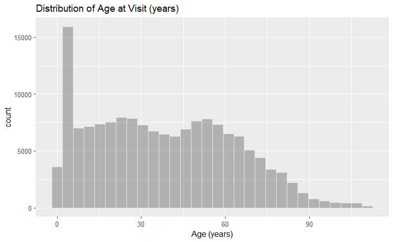

```r
# this histogram has 30 bins
mydata %>%
  ggplot(aes(x=age_at_visit_years)) +
  geom_histogram(bins=30, color="#e9ecef", alpha=0.4) +
    labs(title = "Distribution of Age at Visit (years)") +
      xlab("Age (years)")
```

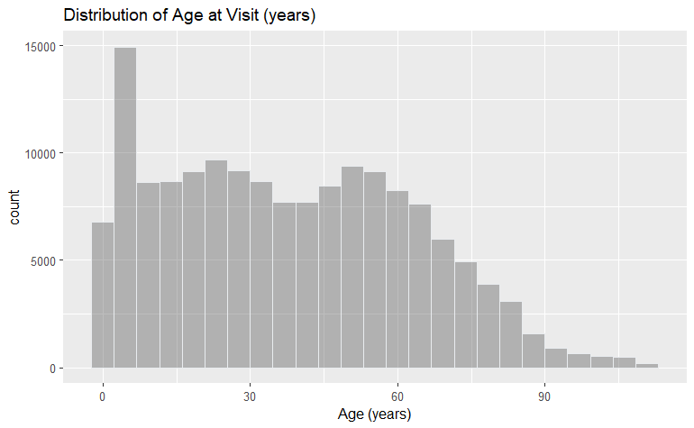

```r
# this histogram only has 25 bins
mydata %>%
  ggplot(aes(x=age_at_visit_years)) +
  geom_histogram(bins=25, color="#e9ecef", alpha=0.4) +
    labs(title = "Distribution of Age at Visit (years)") +
      xlab("Age (years)")
```

```r
NA
NA
```

Boxplots are another way to show distributions.

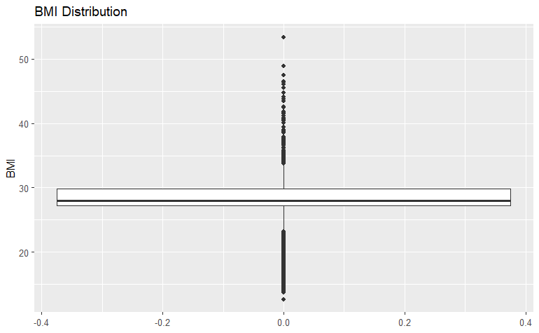

```r
# boxplot of BMI
ggplot(data=subset(mydata, !is.na(bmi)), aes(y=bmi)) +
    geom_boxplot() +
    ggtitle("BMI Distribution") +
    ylab("BMI")
```

Let’s also look at the distribution of the length of stay.

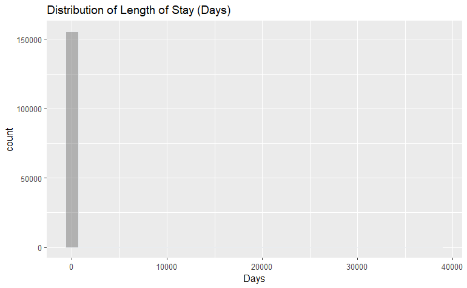

```r
mydata %>%
  ggplot(aes(x=los)) +
  geom_histogram(bins=30, color="#e9ecef", alpha=0.4) +
    labs(title = "Distribution of Length of Stay (Days)") +
      xlab("Days")
```

```r
NA
NA
```

Running this code shows there is clearly a value that makes no sense!

We can look in the data for which observations may be causing this issue. We’ll look at visits that are not outpatient visits that do have more than 100 days in the hospital.

```r
mydata %>%
  filter(los > 100, visit_type != 'Outpatient Visit')
```

| person_id | birth_datetime | race_source_value | ethnicity_source_value | gender_source_value | visit_occurrence_id | visit_start_date | visit_end_date | visit_type | condition | observation_source | age_at_visit_years | measurement_Date | body_height_cm | bmi | body_temperature_c | body_weight_kg | systolic | diastolic | heart_rate_bpm | oxygen_saturation_percent | respiratory_rate_per_minute | flu_last_administered | tdap_last_administered | mmr_last_administered | polio_last_administered | deceased | los | deceased_flag | visit_year | … |
| --- | --- | --- | --- | --- | --- | --- | --- | --- | --- | --- | --- | --- | --- | --- | --- | --- | --- | --- | --- | --- | --- | --- | --- | --- | --- | --- | --- | --- | --- | --- |
| 843 | 1936-07-30 | white | nonhispanic | F | 20871 | 1979-07-20 | 1994-05-06 | Inpatient Visit | Non-small cell carcinoma of lung, TNM stage 1:Non-small cell lung cancer | Suspected lung cancer | 42.97 |  | NA | NA | NA | NA | NA | NA | NA | NA | NA | 1978-11-22 | 1978-07-30 | 1940-07-30 | 1940-07-30 | Y | 5404 | Deceased | 1979 | … |
| 1876 | 1960-07-23 | asian | nonhispanic | F | 46292 | 2006-07-12 | 2018-03-04 | Inpatient Visit | Emphysematous bronchitis |  | 45.97 |  | NA | NA | NA | NA | NA | NA | NA | NA | NA | 2005-09-08 | 2002-07-23 | 1964-07-23 | 1964-07-23 | N | 4253 | Alive | 2006 | … |
| 8484 | 1921-12-19 | white | nonhispanic | F | 213316 | 1967-12-09 | 2003-01-22 | Inpatient Visit | Chronic sinusitis |  | 45.97 |  | NA | NA | NA | NA | NA | NA | NA | NA | NA | 1966-10-04 | 1963-12-19 | 1925-12-19 | 1925-12-19 | Y | 12828 | Deceased | 1967 | … |
| 9327 | 1955-06-18 | white | nonhispanic | M | 233448 | 2018-08-11 | 2019-06-02 | Inpatient Visit | Viral sinusitis | Tobacco smoking status | 63.15 | 2018-10-06 | 182.6 | 30.1 | NA | 100.2 | 138 | 74 | 97.0 | NA | 13.0 | 2017-11-07 | 2017-06-18 | 1959-06-18 | 1959-06-18 | Y | 295 | Deceased | 2018 | … |
| 9715 | 1951-12-03 | white | nonhispanic | F | 242597 | 2013-11-17 | 2020-03-17 | Inpatient Visit | Wheezing:Dyspnea:Cough | Suspected COVID-19 | 61.96 | 2020-03-11 | NA | NA | 39.1 | 69.4 | 129 | 81 | 193.2 | 85.2 | 22.4 | 2012-12-22 | 2003-12-03 | 1955-12-03 | 1955-12-03 | N | 2312 | Alive | 2013 | … |
| 9715 | 1951-12-03 | white | nonhispanic | F | 242598 | 2019-07-18 | 2020-03-17 | Inpatient Visit | Respiratory distress:Pneumonia | Tobacco smoking status | 67.62 | 2020-03-11 | NA | NA | 41.4 | 69.4 | 127 | 79 | 166.6 | 87.5 | 16.9 | 2018-12-09 | 2013-12-03 | 1955-12-03 | 1955-12-03 | Y | 243 | Deceased | 2019 | … |
| 14848 | 1992-03-28 | white | nonhispanic | F | 375742 | 2006-12-18 | 2014-07-27 | Inpatient Visit | Pulmonary emphysema |  | 14.72 |  | NA | NA | NA | NA | NA | NA | NA | NA | NA | 2005-09-23 | 2004-03-28 | 1996-03-28 | 1996-03-28 | N | 2778 | Alive | 2006 | … |
| 16297 | 1936-08-04 | white | hispanic | F | 414146 | 1982-07-24 | 2020-03-20 | Inpatient Visit | Acute respiratory distress syndrome:Acute respiratory distress syndrome | Tobacco smoking status | 45.97 | 2019-06-11 | 166.5 | 28.1 | NA | 77.8 | 124 | 76 | 72.0 | NA | 12.0 | 1981-11-08 | 1978-08-04 | 1940-08-04 | 1940-08-04 | N | 13754 | Alive | 1982 | … |
| 16297 | 1936-08-04 | white | hispanic | F | 414147 | 1990-04-15 | 2020-03-20 | Inpatient Visit | Chronic sinusitis:Chronic sinusitis | Tobacco smoking status | 53.69 | 2019-09-10 | 166.5 | 28.1 | NA | 77.8 | 112 | 78 | 83.0 | NA | 15.0 | 1989-09-02 | 1988-08-04 | 1940-08-04 | 1940-08-04 | N | 10932 | Alive | 1990 | … |
| 16297 | 1936-08-04 | white | hispanic | F | 414144 | 1996-12-09 | 2020-03-20 | Inpatient Visit | Pneumonia:Respiratory distress:Pneumonia:Acute respiratory failure:Pneumonia:Respiratory distress:Acute respiratory failure:Respiratory distress:Acute respiratory failure | Tobacco smoking status | 60.35 | 2019-04-09 | 166.5 | 28.1 | NA | 77.8 | 134 | 78 | 92.0 | NA | 12.0 | 1995-10-26 | 1988-08-04 | 1940-08-04 | 1940-08-04 | N | 8502 | Alive | 1996 | … |

[output cut: 48 more lines]

```r
NA
```

Let’s just look at values that are less than 100 days and that are not outpatient visits

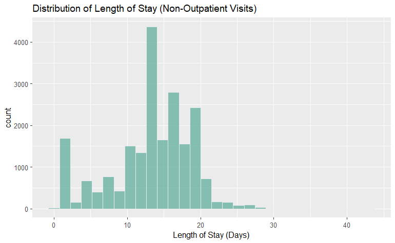

```r
mydata %>%
  filter(los < 100, visit_type != 'Outpatient Visit') %>%
  ggplot(aes(x=los)) +
    geom_histogram(fill="#69b3a2", color="#e9ecef", alpha=0.8, bins=30) +
      labs(title ="Distribution of Length of Stay (Non-Outpatient Visits)") +
      xlab("Length of Stay (Days)")
```

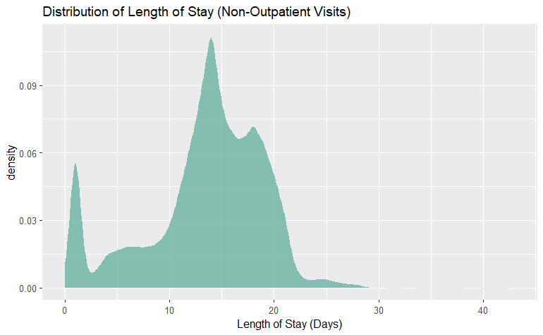

```r
mydata %>%
  filter(los < 100, visit_type != 'Outpatient Visit') %>%
  ggplot(aes(x=los)) +
    geom_density(fill="#69b3a2", color="#e9ecef", alpha=0.8) +
      labs(title ="Distribution of Length of Stay (Non-Outpatient Visits)") +
      xlab("Length of Stay (Days)")
```

### Histogram and Density across groups

We can make histograms and density plots of any continuous variable grouped by a second variable.

Here are some of blood pressure by gender.

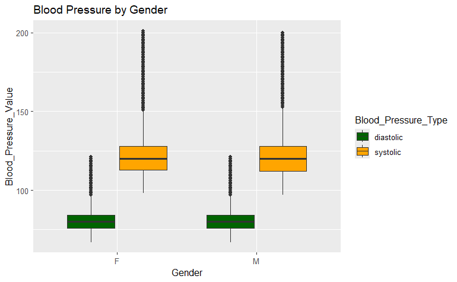

```r
# create a new dataset that is long-- with a row for systolic and a row for diastolic blood pressure per visit and person

bplong <- mydata %>%
  pivot_longer(cols = systolic:diastolic, names_to = 'Blood_Pressure_Type', values_to = 'Blood_Pressure_Value' )

bplong %>%
  filter(!is.na(Blood_Pressure_Value)) %>%
  ggplot(aes(x=gender_source_value, y=Blood_Pressure_Value , fill=Blood_Pressure_Type)) +
  geom_boxplot() +
    scale_fill_manual(values=c("darkgreen", "orange")) +
    labs(title = "Blood Pressure by Gender") +
      xlab("Gender")
```

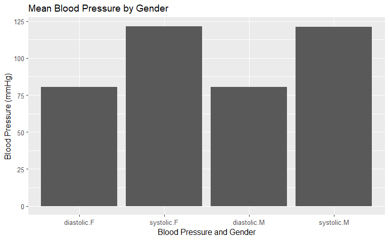

```r
bplong %>%
  filter(!is.na(Blood_Pressure_Value)) %>%
  ggplot(aes(x = interaction(Blood_Pressure_Type, gender_source_value), y = Blood_Pressure_Value)) +
  geom_bar(stat = 'summary', fun = 'mean') +
  labs(title = "Mean Blood Pressure by Gender") +
  xlab("Blood Pressure and Gender") +
  ylab("Blood Pressure (mmHg)")
```

You can also overlay the distributions of blood pressure by gender and have panels in your plot for systolic and diastolic.

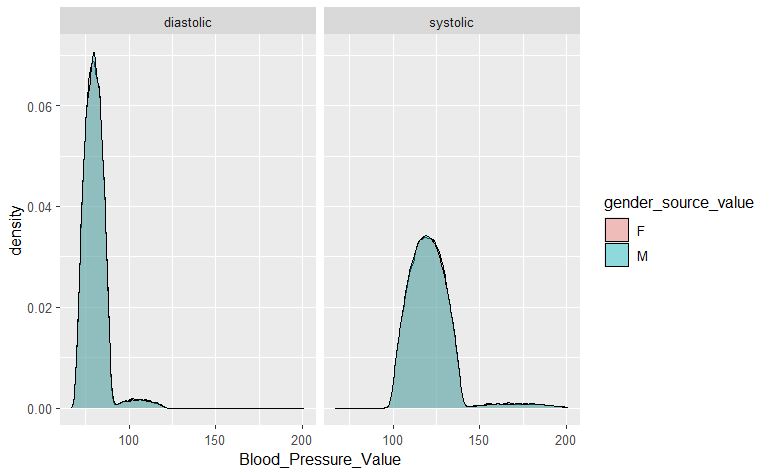

```r
bp <- ggplot(bplong %>% filter(!is.na(Blood_Pressure_Value)), aes(x = Blood_Pressure_Value, fill=gender_source_value)) +
  geom_density(alpha = 0.4) +
  scale_color_manual(values = c("pink", "lightblue")) +
  facet_wrap(~Blood_Pressure_Type)

bp
```

Now let’s look at a comparison of length of stay for inpatient visits by gender.

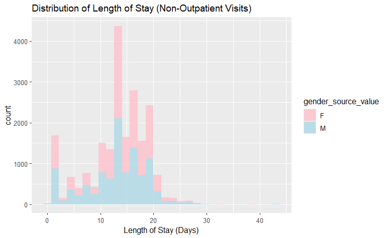

```r
# Histogram
mydata %>%
  filter(los < 100, visit_type != 'Outpatient Visit') %>%
  ggplot(aes(x=los,fill=gender_source_value)) +
    geom_histogram(alpha=0.8, bins=30) +
    scale_fill_manual(values=c("pink", "lightblue")) +
      labs(title ="Distribution of Length of Stay (Non-Outpatient Visits)") +
      xlab("Length of Stay (Days)")
```

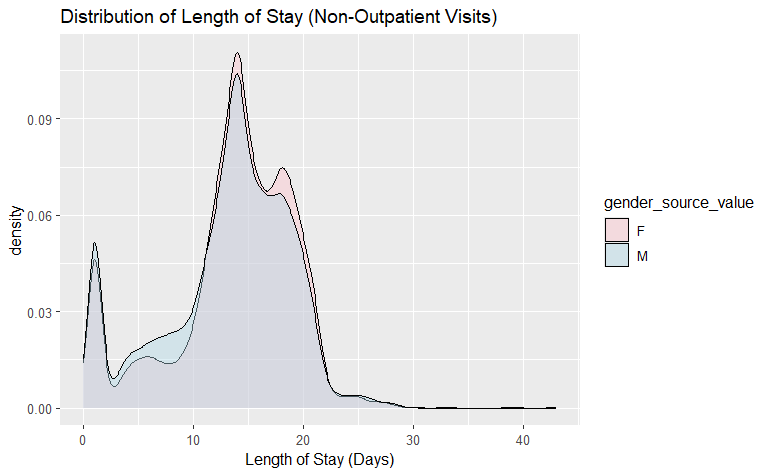

```r
# Density plots
mydata %>%
  filter(los < 100, visit_type != 'Outpatient Visit') %>%
  ggplot(aes(x=los, fill=gender_source_value)) +
    geom_density( alpha=0.4) +
    scale_fill_manual(values=c("pink", "lightblue"))+
      labs(title ="Distribution of Length of Stay (Non-Outpatient Visits)") +
      xlab("Length of Stay (Days)")
```

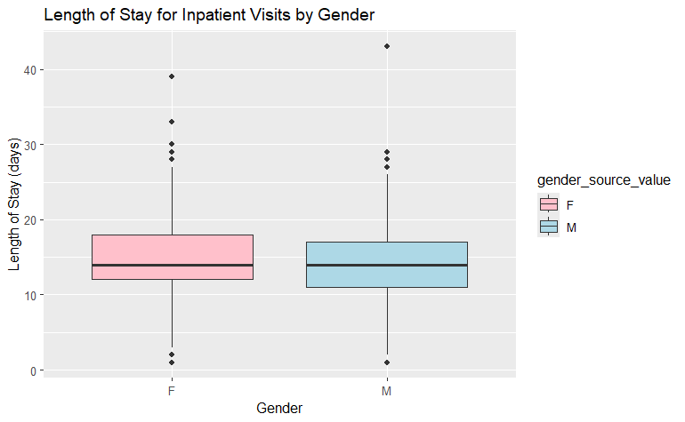

```r
# Boxplots

mydata %>%
  filter(los < 100, visit_type == 'Inpatient Visit') %>%
  ggplot(aes(y=los, x=gender_source_value, fill=gender_source_value)) +
  geom_boxplot() +
  scale_fill_manual(values=c("pink", "lightblue")) +
    labs(title = "Length of Stay for Inpatient Visits by Gender") +
      xlab("Gender") +
      ylab("Length of Stay (days)")
```

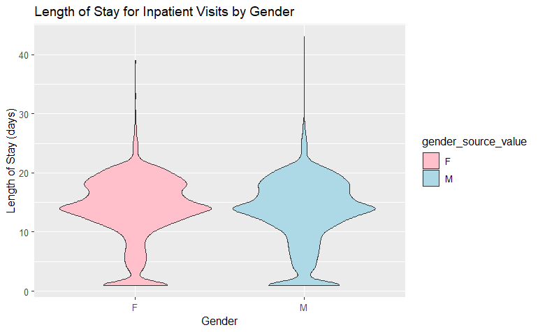

```r
# Violin Plots


mydata %>%
  filter(los < 100, visit_type == 'Inpatient Visit') %>%
  ggplot(aes(y=los, x=gender_source_value, fill=gender_source_value)) +
  geom_violin() +
  scale_fill_manual(values=c("pink", "lightblue")) +
    labs(title = "Length of Stay for Inpatient Visits by Gender") +
      xlab("Gender") +
      ylab("Length of Stay (days)")
```

There are a lot of ways to explore relationships between continuous data, as well.

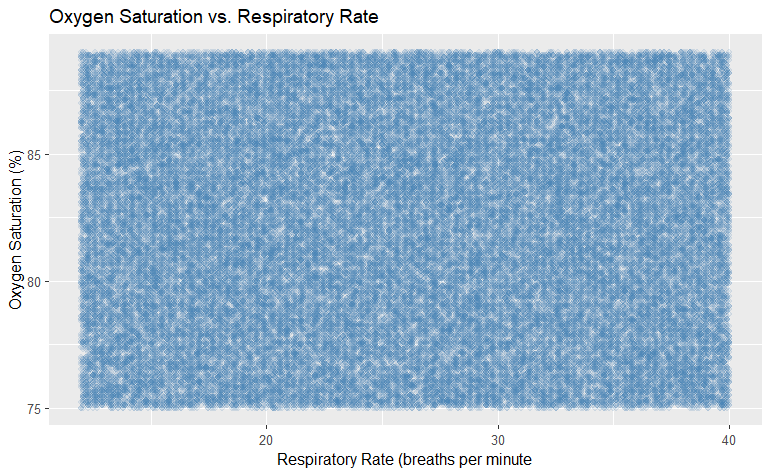

```r
mydata %>%
  filter(!is.na(respiratory_rate_per_minute)) %>%
  filter(!is.na(oxygen_saturation_percent)) %>%
  ggplot(aes(x = respiratory_rate_per_minute, y = oxygen_saturation_percent)) +
  geom_point(color='steelblue', alpha = .1) +
  labs(title ="Oxygen Saturation vs. Respiratory Rate") +
  xlab("Respiratory Rate (breaths per minute") +
  ylab("Oxygen Saturation (%)")
```

We can also look at age versus oxygen saturation by outcome.

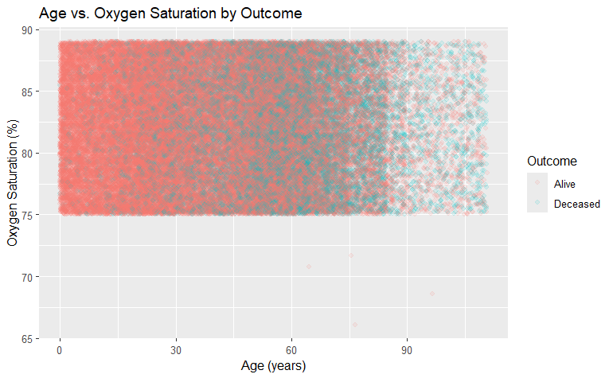

```r
mydata %>%
  filter(!is.na(oxygen_saturation_percent)) %>%
  filter(!is.na(age_at_visit_years)) %>%
  ggplot(aes(x = age_at_visit_years, y = oxygen_saturation_percent, color=deceased_flag)) +
  geom_point(alpha = .1) +
  labs(title ="Age vs. Oxygen Saturation by Outcome", color = "Outcome") +
  xlab("Age (years)") +
  ylab("Oxygen Saturation (%)")
```

```r
NA
```

Here’s another comparison with age.

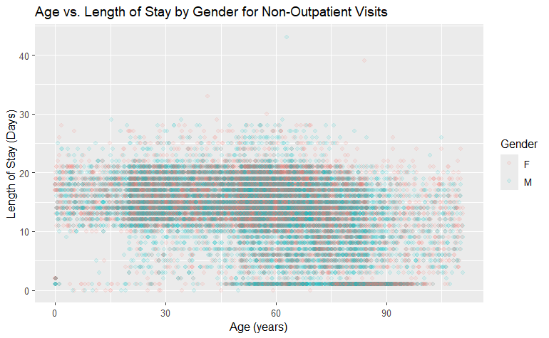

```r
mydata %>%
  filter(los < 100, visit_type != 'Outpatient Visit', !is.na(age_at_visit_years), !is.na(gender_source_value)) %>%
  ggplot(aes(x = age_at_visit_years, y = los, color=gender_source_value)) +
  geom_point(alpha = .1) +
  labs(title ="Age vs. Length of Stay by Gender for Non-Outpatient Visits", color = "Gender") +
  xlab("Age (years)") +
  ylab("Length of Stay (Days)")
```

```r
NA
NA
```

We can also look at visit counts over time! These data come from a simluated dataset based on COVID data.

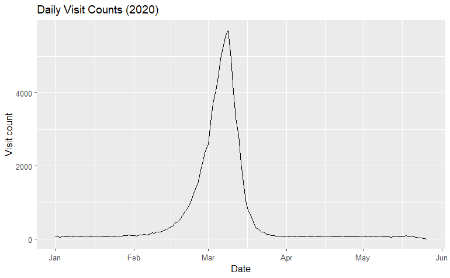

```r
data2020 = mydata %>% filter(visit_year == 2020)
visitcounts = count(data2020, visit_start_date)


visitcounts %>%
  ggplot(aes(x=visit_start_date, y=n)) +
  geom_line() +
  xlab("Date") +
  ylab("Visit count") +
  labs(title = "Daily Visit Counts (2020)")
```

```r
NA
NA
```

Let’s categorize visits as COVID-related or non-COVID-related and plot both series.

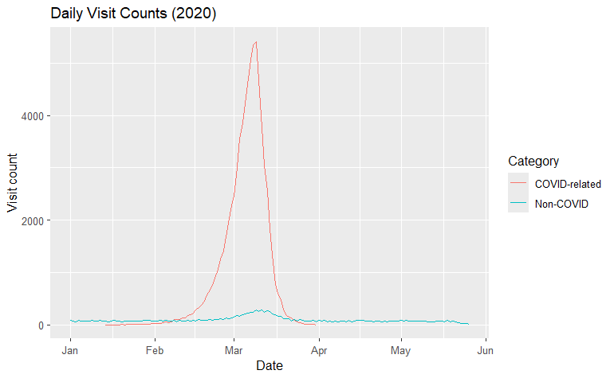

```r
data2020$COVID = grepl('COVID',data2020$observation_source, fixed = TRUE)

COVIDvisitcounts = count(data2020, visit_start_date, COVID)

COVIDvisitcounts$COVID_formatted = ifelse(COVIDvisitcounts$COVID == TRUE, "COVID-related", "Non-COVID")


COVIDvisitcounts %>%
  ggplot(aes(x=visit_start_date, y=n, color=COVID_formatted)) +
  geom_line() +
  xlab("Date") +
  ylab("Visit count") +
  labs(title = "Daily Visit Counts (2020)", color="Category")
```

```r
NA
NA
NA
NA
```